# Comprehensive characterization of patient-derived xenograft models

Adran Lopez, Sergi Boluda i Mireia Fabregas

19/03/2026

# **PART A**

## Where and why was the information collected?

The information was collected from patient-derived xenograft (PDX) models developed by institutions participating in the **NCI Patient-Derived Xenograft Development and Trial Centers Research Network (PDXNet)** and the **National Cancer Institute Patient-Derived Models Repository (PDMR)**.

These models originate from tumor samples donated by cancer patients at participating research hospitals and cancer centers. The tumors were implanted into mice to create patient-derived xenograft (PDX) models.

Each model is catalogued with information such as:

- PDX model ID
- Cancer type
- Patient clinical details
- Tissue origin
- Contributing institution

All of this was done because they wanted to catalog the PDX tumor models used in the study and support genomic analysis and target cancer therapy research. So they wanted to document and organize the full set of PDX models. Also provide transparency and reproducibility so other researchers know exactly which models were analyzed. They wanted to link genomic data to specific tumor models, which then helped to identify models suitable for drug testing and precision cancer research. ANd finally they wanted to create a standardized resource that scientists can reuse for future cancer studies.

## Which is the meaning of each variable?

There are 32 variables in our data describing each PDX model and its sequencing information.

#### **Patient & Sample Information**

Variable

Meaning

Formal_CaseID

Is the unique identifier for the patient case from which the tumor sample originated.

Gender

Biological sex of the patient (Female/Male).

Age

Age of the patient when the tumor sample was collected.

Race

The patient reported racial background.

Source

Institution or centre where the PDX model was generated or contributed to.

ModelID_proper_v3

Standardized ID for the PDX model used in the dataset.

NCI_Passage

Number of passages (times the tumor has been transplanted between mice).  
In PDX models a tumor of a patient is implemented into a mouse. Each transplant is called a passage:

- Passage 1 (P1) → First mouse
- Passage 2 (P2) → Second mouse

Original_SampleID

Identifier for the original tumor sample collected from the patient.

Group

Group classification used in the study dataset.

TumorStatus

Indicates if the tumor sample is primary or metastatic.

#### **Cancer classification**

| Variable | Meaning |
| --- | --- |
| CancerGroup | Category of cancer (e.g., gastrointestinal, breast, lung…). |
| CancerType | Specific type. |
| Diagnosis | Detailed pathological diagnosis of the tumor. |
| TreatmentPriorToCollection | Whether the patient received treatment before the tumor sample was collected. |

#### **Sequencing data**

| Variable | Meaning |
| --- | --- |
| DataType | Type of genomic data generated (e.g., WES). |
| Total_reads | Total number of sequencing reads produced. |
| Mapped(%) | Percentage of reads successfully aligned. |
| MappedReads (M) | Number of mapped reads (in millions). |
| Duplicates(%) | Percentage of duplicated reads detected. |
| AvarageReadsLength(bp) | Average length of sequencing reads (base pairs). |
| MeanMappingQuality | Average quality score for read alignment. |
| AvarageInserSize(bp) | Average DNA fragment size between paired reads. |
| MeanTargetCoverage(MQ20) | Average sequencing coverage of the target region with quality ≥ 20. |

#### **Tumor genomic characteristics**

Variable

Meaning

Purity

Estimated proportion of tumor cells in the sample.

Ploidy

Number of chromosome sets in the tumor genome.

MSI_Score

Microsatellite instability score (measure of genomic instability).

- Low score → stable (MSS)
- High score → instability (MSI)

MSI_Tool

Software used to calculate the MSI score.

#### **Data Management IDs**

| Variable | Meaning |
| --- | --- |
| Analysis_Group | Grouping used for genomic analysis based on data quality and filtering criteria. |
| Analysis_ID | Unique identifier for a specific analysis dataset. |
| SampleInfo_ID | Identifier linking to additional sample metadata. |
| ModelID_alt | Alternative ID used for the same PDX model. |

## Do the variables have units? Which one?

Some of the variables have measures of units, while others are categorical. The ones with units are summarized in the table below:

| Variable | Unit / Measurement |
| --- | --- |
| **Age** | years |
| **Total_reads** | number of reads |
| **MappedReads** | millions of reads |
| **Mapped(%)** | % |
| **Duplicates(%)** | % |
| **AvarageReadsLength(bp)** | base pairs (bp) |
| **MaximumReadsLength(bp)** | base pairs (bp) |
| **AvarageInsertSize(bp)** | base pairs (bp) |
| **MeanTargetCoverage(MQ20)** | sequencing depth (x coverage) |
| **Purity** | proportion (0-1 or %) |
| **Ploidy** | copy number |
| **MSI_Score** | score/index |

> **Note:** `NCI_Passage` is recorded as a **count** (number of transplantation events) rather than a physical unit of measurement.

## Does the data set have a long format?

No, the dataset is not in long format, it is in wide format. Each row represents one observation and each column represents a different variable describing that observation.

# **PART B**

Our first step involves importing the raw dataset directly from its web source into the R environment. Once the data is loaded, we will perform an initial structural audit to determine if the data is ‘tidy’ or if it requires reshaping into a long format to facilitate effective visualization.

```r
url <- "https://static-content.springer.com/esm/art%3A10.1038%2Fs41467-021-25177-3/MediaObjects/41467_2021_25177_MOESM5_ESM.xlsx"

download.file(url, destfile = "tableS1.xlsx", mode = "wb")

data <- read_excel("tableS1.xlsx", skip = 1)

# First 6 rows
kable(head(data), "html") %>%
  kable_styling(bootstrap_options = c("striped", "hover", "condensed", "responsive")) %>%
  scroll_box(width = "100%", height = "300px") %>%
row_spec(0, bold = T, color = "white", background = "#2780e3")
```

| Formal_CaseID | Gender | Age | Race | Source | ModelID_proper_v3 | NCI_Passage | Original_SampleID | Group | TumorStatus | CancerGroup | CancerType | Diagnosis | TreatmentPriorToCollection | DataType | Total_reads | Mapped(%) | MappedReads(M) | Duplicates(%) | AverageReadsLength(bp) | MaximumReadsLength(bp) | MeanMappingQuality | AverageInsertSize(bp) | MeanTargetCoverage(MQ20) | Purity | Ploidy | MSI_Score | MSI_Tool | Analysis_Group | Analysis_ID | … |
| --- | --- | --- | --- | --- | --- | --- | --- | --- | --- | --- | --- | --- | --- | --- | --- | --- | --- | --- | --- | --- | --- | --- | --- | --- | --- | --- | --- | --- | --- | --- |
| HCI-HCI004 | Female | 55-59 | Unknown | HCI | NA | HN | HCI-004_Patient_normal | Human_Normal | NA | Breast | BRCA | Invasive ductal carcinoma | NA | WES | 136141415 | 99.90 | 136.01085 | 0 | 124 | 125 | 36.9 | 250.0 | 140.77 | NA | NA | NA | NA | TumorNormal | 14990X4_HCI004_patientnormalGU | … |
| HCI-HCI008 | Female | 85-89 | Caucasian | HCI | NA | HN | HCI-008_Patient_normal | Human_Normal | NA | Breast | BRCA | Inflammatory breast carcinoma | NA | WES | 60432235 | 99.84 | 60.33839 | 0 | 97 | 101 | 36.6 | 240.1 | 57.67 | NA | NA | NA | NA | TumorNormal | 1007649-B_HCI-008_Patient_normal | … |
| HCI-HCI010 | Female | 45-49 | Caucasian | HCI | NA | HN | HCI-010_Patient_normal | Human_Normal | NA | Breast | BRCA | Invasive ductal carcinoma | NA | WES | 67156718 | 99.88 | 67.07818 | 0 | 92 | 101 | 35.9 | 237.0 | 58.32 | NA | NA | NA | NA | TumorNormal | 0903211-B_HCI-010_Patient_normal | … |
| HCI-HCI018 | Female | 45-49 | Caucasian | HCI | NA | HN | HCI-018_Patient_normal | Human_Normal | NA | Breast | BRCA | Invasive lobular carcinoma | NA | WES | 92872951 | 99.87 | 92.74989 | 0 | 124 | 125 | 36.7 | 245.0 | 95.33 | NA | NA | NA | NA | TumorNormal | 14990X14_HCI018_patientnormal | … |
| HCI-HCI019 | Female | 55-59 | Unknown | HCI | NA | HN | HCI-019_Patient_normal | Human_Normal | NA | Breast | BRCA | Invasive ductal carcinoma | NA | WES | 116738273 | 99.92 | 116.63969 | 0 | 123 | 125 | 36.2 | 245.3 | 142.79 | NA | NA | NA | NA | TumorNormal | 15306X1_HCI019_patientnormalGU | … |
| HCI-HCI023 | Female | 50-54 | Caucasian | HCI | NA | HN | HCI-023_Patient_normal | Human_Normal | NA | Breast | BRCA | Invasive ductal carcinoma | NA | WES | 103076059 | 99.86 | 102.93376 | 0 | 124 | 125 | 36.9 | 245.7 | 115.20 | NA | NA | NA | NA | TumorNormal | 14990X18_HCI023_patientnormal | … |

```r
# We check the variables format and type and if have NAs
na_summary <- data.frame(
  Variable = names(data),
  Type = sapply(data, class),
  Missing_Values = sapply(data, function(x) sum(is.na(x)))
)


na_summary %>%
  kable(
    col.names = c("Variable Name", "Data Type", "Count of NAs"),
    caption = "<center><b>Data Structure and Quality Summary</b></center>",
    row.names = FALSE
  ) %>%
  kable_styling(
    bootstrap_options = c("striped", "hover", "condensed"),
    full_width = F,
    position = "left"
  ) %>%
  row_spec(0, bold = T, color = "white", background = "#2780e3") %>%


scroll_box(height = "400px", width = "100%")
```

**Data Structure and Quality Summary**

| Variable Name | Data Type | Count of NAs |
| --- | --- | --- |
| Formal_CaseID | character | 0 |
| Gender | character | 0 |
| Age | character | 0 |
| Race | character | 0 |
| Source | character | 0 |
| ModelID_proper_v3 | character | 0 |
| NCI_Passage | character | 0 |
| Original_SampleID | character | 0 |
| Group | character | 0 |
| TumorStatus | character | 0 |
| CancerGroup | character | 0 |
| CancerType | character | 0 |
| Diagnosis | character | 0 |
| TreatmentPriorToCollection | character | 0 |
| DataType | character | 0 |
| Total_reads | numeric | 0 |
| Mapped(%) | numeric | 0 |
| MappedReads(M) | numeric | 0 |
| Duplicates(%) | numeric | 0 |
| AverageReadsLength(bp) | numeric | 0 |
| MaximumReadsLength(bp) | numeric | 0 |
| MeanMappingQuality | numeric | 0 |
| AverageInsertSize(bp) | numeric | 0 |
| MeanTargetCoverage(MQ20) | numeric | 0 |
| Purity | character | 0 |
| Ploidy | character | 0 |
| MSI_Score | character | 0 |
| MSI_Tool | character | 0 |
| Analysis_Group | character | 0 |
| Analysis_ID | character | 0 |
| SampleInfo_ID | character | 0 |
| ModelID_alt | character | 0 |

## Data Overview

As we can see from the summary and by inspecting the `.xlsx` file, there are several issues with the dataset:

- Some variables are stored as strings but should be treated as categorical
- Some variables contain `"NA"` or `"Unknown"` as strings → these should be converted to proper `NA` values
  - Note: numerical variables already have missing values correctly handled
- Some character (`chr`) variables should actually be numerical

### **Main Concern**

Although the most concerning issue is the following:

*If the study reports **500+ patients**, why does the dataset contain **3000+ rows**?*

This suggests that there may be multiple records per patient or potential duplication issues.

### **Next Steps**

To better understand this, we will:

- Check unique values in individual variables
- Combine variables to identify inconsistencies or duplications

```r
# We first check the total number of rows in our data
# nrow(data) --> 3705

# First we check the Patients_ID (how many unique ones there are)
# length(unique(data$Formal_CaseID)) --> 511

# We will use dplyr
# Then we continue by adding the SampleID -> 2304
# data %>%
  # distinct(Formal_CaseID, Original_SampleID) %>%
  # nrow()

# Then with the Group -> 2304
# data %>%
  # distinct(Formal_CaseID, Original_SampleID, Group) %>%
  # nrow()

# Finally with the DataType -> 3702
# data %>%
  # distinct(Formal_CaseID, Original_SampleID, Group, DataType) %>%
  # nrow()

# After checking all of above we create a data frame with all the information to display it at the html
hierarchy_check <- data.frame(
  Level = c("Total Rows in Dataset", "Unique Patient IDs", "Unique Sample IDs", "Unique Patient+Sample+Group+Type"),
  Count = c(
    nrow(data),
    n_distinct(data$Formal_CaseID),
    nrow(distinct(data, Formal_CaseID, Original_SampleID)),
    nrow(distinct(data, Formal_CaseID, Original_SampleID, Group, DataType))
  )
)

hierarchy_check %>%
  kable(col.names = c("Data Level", "Count"), align = "lr") %>%
  kable_styling(bootstrap_options = c("hover", "condensed"), full_width = F, position = "center") %>%
  row_spec(0, bold = T, color = "white", background = "#2780e3") %>% # Header-like style for the total
  row_spec(2, bold = T, color = "#d63031")
```

| Data Level | Count |
| --- | --- |
| Total Rows in Dataset | 3705 |
| Unique Patient IDs | 511 |
| Unique Sample IDs | 2304 |
| Unique Patient+Sample+Group+Type | 3702 |

```r
# We can visualize this with a simple table:

data %>%
  group_by(Group, DataType) %>%
  summarise(
    Patients = n_distinct(Formal_CaseID),
    Total_Samples = n(),
    .groups = "drop"
  ) %>%
  arrange(Group, desc(Patients)) %>%
  kable(caption = "<center><b>Sample Distribution by Group and Technology<b><center>") %>%
  kable_styling(bootstrap_options = c("striped", "hover"), full_width = T) %>%
  # Merges the 'Group' cells so it's easier to read
  collapse_rows(columns = 1, valign = "top") %>%
  row_spec(0, bold = T, color = "white", background = "#2780e3")
```

**Sample Distribution by Group and Technology**

| Group | DataType | Patients | Total_Samples |
| --- | --- | --- | --- |
| Human_Normal | WES | 293 | 293 |
| Human_Tumor | WES | 244 | 254 |
|  | RNA-Seq | 85 | 87 |
| PDX | WES | 511 | 1607 |
|  | RNA-Seq | 432 | 1464 |

## Understanding the Dataset Structure

This gives us valuable information which, together with the paper’s explanation, allows us to further understand what’s happening.

The study design is as follows:

- A cohort of **500+ cancer patients** was selected
- Multiple types of samples were obtained from each patient:
  - **Human_Normal** → Biopsy of healthy tissue
  - **Human_Tumor** → Biopsy of the tumor
  - **PDX** → Xenograft of the tumor in mice

These account for **2304 samples**. The remaining rows arise because:

- The same biological sample was analyzed using different techniques:
  - **WES** (Whole Exome Sequencing)
  - **RNA-Seq**

This results in multiple rows per sample.

### **Implications for the Analysis**

When performing tumor characterization:

- We should focus on **unique Human_Tumor patients**
- Avoid counting duplicated samples coming from different sequencing methods
- Optionally include **PDX** samples if the analysis requires it

### **Next Step: Sample Classification**

Now, we will analyze the samples to determine the group to which each observation belongs.

```r
# Let's see to which groups they belong
group_summary <- data %>%
  group_by(Group) %>%
  summarise(unique_patients = n_distinct(Formal_CaseID)) %>%
  arrange(desc(unique_patients))
# The total sum is over 511, so some patients may be in common

# We make it beautiful
group_summary %>%
  kable(
    col.names = c("Experimental Group", "Unique Patient Count"),
    caption = "<center><b>Distribution of Patients across Groups (Note: Overlaps exist)<b><center>"
  ) %>%
  kable_styling(
    bootstrap_options = c("striped", "hover", "condensed"),
    full_width = F,
    position = "center"
  ) %>%
  # Add a footer to explain the "Oddity" we found
  footnote(general = paste("Total distinct patients in dataset: 511.",
                           "The sum here (", sum(group_summary$unique_patients),
                           ") is higher because patients appear in multiple groups.")) %>%
  row_spec(0, bold = T, color = "white", background = "#2780e3")
```

**Distribution of Patients across Groups (Note: Overlaps exist)**

| Experimental Group | Unique Patient Count |
| --- | --- |
| PDX | 511 |
| Human_Normal | 293 |
| Human_Tumor | 258 |

Note:  
Total distinct patients in dataset: 511. The sum here ( 1062 ) is higher because patients appear in multiple groups.

```r
# Unique Human_Normal patients
human_normal <- data %>%
  filter(Group == "Human_Normal") %>%
  distinct(Formal_CaseID) %>%
  pull(Formal_CaseID)

# Unique Human_Tumor patients
human_tumor <- data %>%
  filter(Group == "Human_Tumor") %>%
  distinct(Formal_CaseID) %>%
  pull(Formal_CaseID)

# Unique PDX patients
pdx_ids <- data %>%
  filter(Group == "PDX") %>%
  distinct(Formal_CaseID) %>%
  pull(Formal_CaseID)

# Check how many patients are in both (intersections)
normal_pdx <- intersect(human_normal, pdx_ids) # -> 293
tumor_pdx <- intersect(human_tumor, pdx_ids) # -> 258
normal_tumor <- intersect(human_normal, human_tumor) # -> 186
all_three <- intersect(intersect(human_tumor, human_normal), pdx_ids) # -> 186



# We create a clean summary of the overlaps
overlap_summary <- data.frame(
  Comparison = c("Normal ∩ PDX", "Tumor ∩ PDX", "Normal ∩ Tumor", "In All Three Groups"),
  Shared_Patients = c(
    length(intersect(human_normal, pdx_ids)),
    length(intersect(human_tumor, pdx_ids)),
    length(intersect(human_normal, human_tumor)),
    length(all_three)
  )
)

overlap_summary %>%
  kable(caption = "<center><b>Patient Overlap Analysis across Experimental Groups<b><center>", align = "lc") %>%
  kable_styling(bootstrap_options = c("striped", "hover", "condensed"), full_width = F) %>%
  row_spec(0, bold = T, color = "white", background = "#2780e3") %>%
  row_spec(4, bold = T, color = "#d63031") %>%
  column_spec(2, bold = T)
```

**Patient Overlap Analysis across Experimental Groups**

| Comparison | Shared_Patients |
| --- | --- |
| Normal ∩ PDX | 293 |
| Tumor ∩ PDX | 258 |
| Normal ∩ Tumor | 186 |
| In All Three Groups | 186 |

## Sample Relationships and Study Focus

From the dataset, we observe the following:

- All **Human_Normal** samples have a corresponding **PDX**
- All **Human_Tumor** samples have a corresponding **PDX**
- Most **Human_Normal** samples originate from **Human_Tumor** patients

In other words, this indicates that the main focus of the study is on **PDX models**, which explains the presence of additional **PDX samples** that do not directly correspond to the other groups.

However:

- These extra **PDX samples** are derived from mice
- Our primary interest is in **human data**
- We also want to avoid duplicated samples

### **Analysis Strategy**

To simplify the analysis and avoid inconsistencies:

- For tumor characterization:
  - We will use only **Human_Tumor** individuals
- For comparisons involving PDX:
  - We will use the **corresponding PDX sample** for each patient

### **Data Cleaning**

After addressing the dataset structure, we can now return to the previously identified issues.

We need to clean the dataset before starting the analysis by:

- Identifying variables containing `"NA"` or `"Unknown"` values
- Converting these values into proper `NA`
- Ensuring variable types are correctly defined

To make this process robust and avoid manual errors:

- Instead of reviewing variables one by one
- We will apply a function to automatically detect and handle `"NA"` and `"Unknown"` values across all columns

```r
# Convert "NA" and "Unknown" strings into NA values
for (col in names(data)) {
  # Only act on character or factor columns
  if (is.character(data[[col]])) {
    # Replace "Unknown" or "NA" (string) with actual NA
    data[[col]][data[[col]] %in% c("Unknown", "NA")] <- NA
  }
}

# Count the na values

na_counts <- data.frame(
  Variable = names(data),
  Missing_Values = sapply(data, function(x) sum(is.na(x)))
)

# For making the data beautiful
na_counts %>%
  kable(col.names = c("Column Name", "Total NAs"),
        caption = "<center><b>Missing Value Analysis<center><b>",
        row.names = FALSE) %>%
  kable_styling(bootstrap_options = c("striped", "hover", "condensed"),
                full_width = F,
                position = "center") %>%
  row_spec(0, bold = T, color = "white", background = "#2780e3") %>%
  row_spec(26, bold = T, color = "#d63031") %>%
  row_spec(27, bold = T, color = "#d63031") %>%
  row_spec(28, bold = T, color = "#d63031") %>%
  scroll_box(height = "400px") # Essential for your 32 variables
```

**Missing Value Analysis**

| Column Name | Total NAs |
| --- | --- |
| Formal_CaseID | 0 |
| Gender | 0 |
| Age | 93 |
| Race | 1316 |
| Source | 0 |
| ModelID_proper_v3 | 293 |
| NCI_Passage | 0 |
| Original_SampleID | 0 |
| Group | 0 |
| TumorStatus | 482 |
| CancerGroup | 0 |
| CancerType | 0 |
| Diagnosis | 0 |
| TreatmentPriorToCollection | 425 |
| DataType | 0 |
| Total_reads | 0 |
| Mapped(%) | 0 |
| MappedReads(M) | 0 |
| Duplicates(%) | 0 |
| AverageReadsLength(bp) | 0 |
| MaximumReadsLength(bp) | 0 |
| MeanMappingQuality | 0 |
| AverageInsertSize(bp) | 0 |
| MeanTargetCoverage(MQ20) | 0 |
| Purity | 300 |
| Ploidy | 1851 |
| MSI_Score | 1844 |
| MSI_Tool | 1844 |
| Analysis_Group | 0 |
| Analysis_ID | 0 |
| SampleInfo_ID | 0 |
| ModelID_alt | 293 |

```r
# Convert categorical variables to factors - We manually check that
# List of variables to convert to factors
categorical_vars <- c( "Gender", "Age", "Race", "Source", "ModelID_proper_v3", "NCI_Passage", "Group", "TumorStatus", "CancerGroup", "CancerType", "Diagnosis", "TreatmentPriorToCollection", "DataType", "MSI_Tool", "Analysis_Group" )

for (col in categorical_vars) {
  data[[col]] <- as.factor(data[[col]])
}

# Convert chr variables to numerical
data$Ploidy <- as.numeric(data$Ploidy)
data$MSI_Score <- as.numeric(data$MSI_Score)
data$Purity <- as.numeric(data$Purity)

# Now we can visualize our transformed data
# 1. We create a clean summary data frame of the new structure
data_structure <- data.frame(
  Variable = names(data),
  Class = sapply(data, function(x) paste(class(x), collapse = ", ")),
  Preview = sapply(data, function(x) {
    # Get a glimpse of the first few values, truncated for the table
    vals <- head(na.omit(x), 3)
    if(length(vals) == 0) return("All NA")
    paste(vals, collapse = ", ")
  })
)

# 2. Render it to make it look good
data_structure %>%
  kable(
    col.names = c("Column Name", "Data Type", "Value Preview (First 3)"),
    caption = "<center><b>Final Processed Data Structure<b><center>",
    row.names = FALSE
  ) %>%
  kable_styling(
    bootstrap_options = c("striped", "hover", "condensed", "responsive"),
    full_width = TRUE
  ) %>%
  row_spec(0, bold = T, color = "white", background = "#2780e3") %>%
  scroll_box(height = "500px")
```

**Final Processed Data Structure**

| Column Name | Data Type | Value Preview (First 3) |
| --- | --- | --- |
| Formal_CaseID | character | HCI-HCI004, HCI-HCI008, HCI-HCI010 |
| Gender | factor | Female, Female, Female |
| Age | factor | 55-59, 85-89, 45-49 |
| Race | factor | Caucasian, Caucasian, Caucasian |
| Source | factor | HCI, HCI, HCI |
| ModelID_proper_v3 | factor | HCI002, HCI003, HCI004 |
| NCI_Passage | factor | HN, HN, HN |
| Original_SampleID | character | HCI-004_Patient_normal, HCI-008_Patient_normal, HCI-010_Patient_normal |
| Group | factor | Human_Normal, Human_Normal, Human_Normal |
| TumorStatus | factor | Primary, Primary, Primary |
| CancerGroup | factor | Breast, Breast, Breast |
| CancerType | factor | BRCA, BRCA, BRCA |
| Diagnosis | factor | Invasive ductal carcinoma, Inflammatory breast carcinoma, Invasive ductal carcinoma |
| TreatmentPriorToCollection | factor | No, No, No |
| DataType | factor | WES, WES, WES |
| Total_reads | numeric | 136141415, 60432235, 67156718 |
| Mapped(%) | numeric | 99.9, 99.84, 99.88 |
| MappedReads(M) | numeric | 136.010847, 60.338387, 67.078179 |
| Duplicates(%) | numeric | 0, 0, 0 |
| AverageReadsLength(bp) | numeric | 124, 97, 92 |
| MaximumReadsLength(bp) | numeric | 125, 101, 101 |
| MeanMappingQuality | numeric | 36.9, 36.6, 35.9 |
| AverageInsertSize(bp) | numeric | 250, 240.1, 237 |
| MeanTargetCoverage(MQ20) | numeric | 140.77, 57.67, 58.32 |
| Purity | numeric | 0.86, 0.28, 0.66 |
| Ploidy | numeric | 2.17, 5.16, 1.88 |
| MSI_Score | numeric | 1.1, 1.3, 0.32 |
| MSI_Tool | factor | msisensor2, msisensor2, msisensor1 |
| Analysis_Group | factor | TumorNormal, TumorNormal, TumorNormal |
| Analysis_ID | character | 14990X4_HCI004_patientnormalGU, 1007649-B_HCI-008_Patient_normal, 0903211-B_HCI-010_Patient_normal |
| SampleInfo_ID | character | HCI-HCI004.WES.N, HCI-HCI008.WES.N, HCI-HCI010.WES.N |
| ModelID_alt | character | HCI-002, HCI-003, HCI-004 |

## Variable Selection

We will also create a subset of the dataset, keeping only the variables that contain meaningful biological information for our study.

In particular, we will:

- Remove variables that only contain identifiers or technical labels
- Exclude variables that are not relevant for the general analysis
- Discard variables that do not provide useful variability

For example:

- Some genomic-related variables are not required for this analysis
- The variable **“Duplicates (%)”** contains only zeros
  - Therefore, it does not provide any informative value
  - It will be removed, as it does not contribute to exploratory analysis

### **Objective**

The goal of this step is to:

- Reduce noise in the dataset
- Simplify the analysis
- Focus only on variables that provide meaningful insights

```r
# Checking unique values in Duplicates(%) variable
duplicates <- unique(data$`Duplicates(%)`) # We see 0, that is, all values are the same

# List of variables to remove
remove_vars <- c(
  "ModelID_proper_v3",
  "Analysis_ID",
  "SampleInfo_ID",
  "ModelID_alt",
  "Duplicates(%)",
  "MappedReads(M)",
  "AverageReadsLength(bp)",
  "MaximumReadsLength(bp)",
  "AverageInsertSize(bp)"
)

# Subset by removing the unwanted columns
data_clean <- data %>% select(-all_of(remove_vars))

# Structure Summary
data.frame(
  Variable = names(data_clean),
  Class = sapply(data_clean, function(x) paste(class(x), collapse = ", "))
) %>%
  kable(caption = "<center><b>Cleaned Dataset Structure<center><b>",
        row.names = FALSE) %>%
  kable_styling(bootstrap_options = c("striped", "condensed"), full_width = F, position = "left") %>%
  row_spec(0, bold = T, color = "white", background = "#2780e3") %>%
  scroll_box(height = "300px")
```

**Cleaned Dataset Structure**

| Variable | Class |
| --- | --- |
| Formal_CaseID | character |
| Gender | factor |
| Age | factor |
| Race | factor |
| Source | factor |
| NCI_Passage | factor |
| Original_SampleID | character |
| Group | factor |
| TumorStatus | factor |
| CancerGroup | factor |
| CancerType | factor |
| Diagnosis | factor |
| TreatmentPriorToCollection | factor |
| DataType | factor |
| Total_reads | numeric |
| Mapped(%) | numeric |
| MeanMappingQuality | numeric |
| MeanTargetCoverage(MQ20) | numeric |
| Purity | numeric |
| Ploidy | numeric |
| MSI_Score | numeric |
| MSI_Tool | factor |
| Analysis_Group | factor |

```r
data_clean %>%
  select(where(is.numeric)) %>%
  pivot_longer(everything(), names_to = "Variable", values_to = "Value") %>%
  group_by(Variable) %>%
  summarise(
    Min = min(Value, na.rm = TRUE),
    Mean = round(mean(Value, na.rm = TRUE), 2),
    Max = max(Value, na.rm = TRUE),
    NAs = sum(is.na(Value))
  ) %>%
  kable(caption = "<center><b>Numerical Variable Summary Statistics<center><b>") %>%
  kable_styling(bootstrap_options = c("striped", "hover"), full_width = T) %>%
  row_spec(0, bold = T, color = "white", background = "#2780e3")
```

**Numerical Variable Summary Statistics**

| Variable | Min | Mean | Max | NAs |
| --- | --- | --- | --- | --- |
| MSI_Score | 0.00 | 6.42 | 8.95600e+01 | 1844 |
| Mapped(%) | 94.29 | 99.83 | 1.00000e+02 | 0 |
| MeanMappingQuality | 22.90 | 35.31 | 3.97000e+01 | 0 |
| MeanTargetCoverage(MQ20) | 0.00 | 68.26 | 3.26900e+02 | 0 |
| Ploidy | 1.07 | 3.99 | 1.04200e+01 | 1851 |
| Purity | 0.16 | 0.85 | 1.00000e+00 | 300 |
| Total_reads | 20501636.00 | 124720727.91 | 1.03278e+09 | 0 |

## Quality Control Considerations

From the latest `summary()` output, we can extract several important insights. One of the most relevant aspects for the subsequent exploratory analysis is the **quality of the samples**.

In particular, we want to address the following questions:

1. **Is there a difference between samples analyzed with RNA-Seq and WES?**
   - This is important for overall quality control
2. **Is there a difference in quality between MSI tools (msisensor1 vs msisensor2)?**
   - This is relevant for downstream tumor characterization

### **Interpretation Strategy**

- If clear differences are observed between methods or tools:
  - These differences should be considered and potentially highlighted in the analysis
- If no substantial differences are found:
  - We can safely treat the data as comparable across methods

### **Key Question**

For example:

*If some samples were analyzed only using RNA-Seq, while most were analyzed using WES, can both methods be considered of equal quality?*

To answer this, we will compare key quality metrics such as:

- Number of reads
- Percentage of mapping
- Mapping quality

### **Objective**

This step is crucial because:

- If both methods show similar quality:
  - We can treat all samples equally, regardless of their data type
- Otherwise:
  - We may need to account for methodological differences in the analysis

## DataType differences

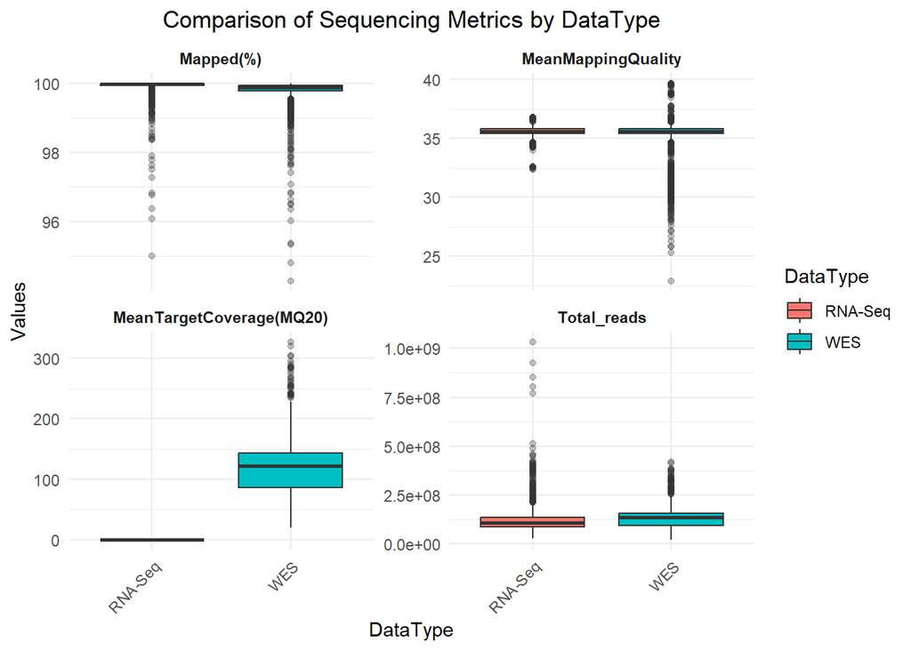

```r
# Select the QC-related variables
data_plot <- data_clean %>%
  select(DataType, Total_reads, `Mapped(%)`, MeanMappingQuality, `MeanTargetCoverage(MQ20)`) %>%
  # Convert to long format for easy comparison
  pivot_longer(
    cols = -DataType,
    names_to = "Metric",
    values_to = "Value"
  )

# Boxplots to compare the results
ggplot(data_plot, aes(x = DataType, y = Value, fill = DataType)) +
  geom_boxplot(outlier.alpha = 0.3) +
  facet_wrap(~Metric, scales = "free_y") +
  theme_minimal() +
  labs(
    title = "Comparison of Sequencing Metrics by DataType",
    x = "DataType",
    y = "Values",
    fill = "DataType"
  ) +
  theme(
    plot.title = element_text(hjust = 0.5),
    axis.text.x = element_text(angle = 45, hjust = 1),
    strip.text = element_text(face = "bold")
  )
```

The graph already reveals several important insights:

- There is no substantial difference between **RNA-Seq** and **WES** samples
- The **MQ20** metric is only computed for **WES** samples
  - This is expected, as MQ20 is associated with targeted sequencing, which is the basis of WES
- There is considerable variability within groups (many outliers)
  - However, the central tendencies (boxplots) remain at similar levels across methods

Overall, these observations suggest that:

- Both sequencing methods show **comparable quality**
- Despite variability, there is no clear systematic bias between **RNA-Seq** and **WES**

To further validate these findings, we will:

- Plot each quality variable individually
- Apply visualization adjustments to better compare boxplot positions

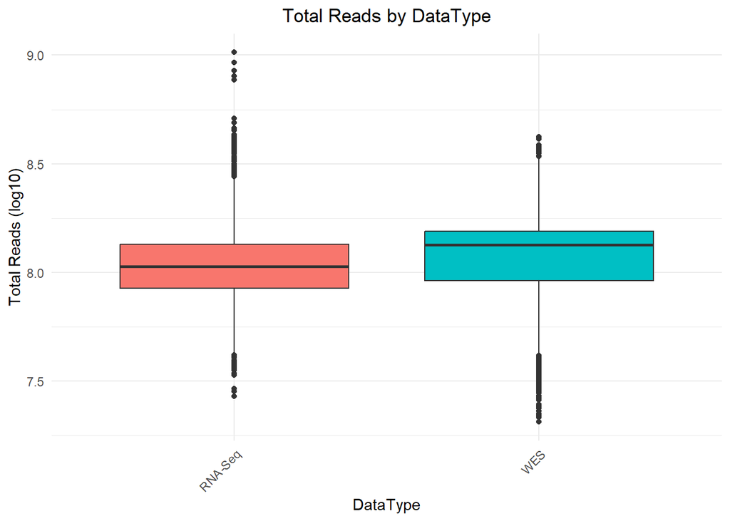

```r
# Total_reads -> We apply a log10() transformation to get rid of the "outliers noise".
ggplot(data_clean, aes(x = DataType, y = log10(Total_reads), fill = DataType)) +
  geom_boxplot() +
  theme_minimal() +
  labs(
    title = "Total Reads by DataType",
    y = "Total Reads (log10)"
  ) +
  theme(plot.title = element_text(hjust = 0.5),
        axis.text.x = element_text(angle = 45, hjust = 1),
        legend.position = "none")
```

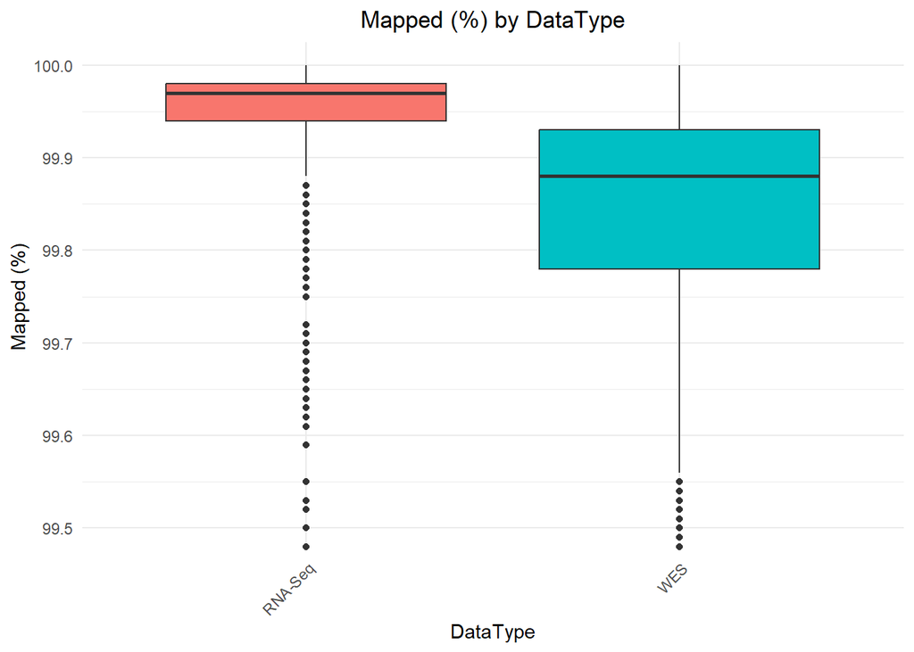

```r
# Mapped(%) -> log10 makes no sense, so, even if it's not the most "Statistically accurate" way of viewing this, we will directly limit the y axis from 99.5 - 100 --> Which is already a lot! Still, most of the samples are >99.7% mapped
ggplot(data_clean, aes(x = DataType, y = `Mapped(%)`, fill = DataType)) +
  geom_boxplot() +
  coord_cartesian(ylim = c(99.5, 100)) +
  theme_minimal() +
  labs(
    title = "Mapped (%) by DataType",
    y = "Mapped (%)"
  ) +
  theme(plot.title = element_text(hjust = 0.5),
        axis.text.x = element_text(angle = 45, hjust = 1),
        legend.position = "none")
```

[figure not shown]

```r
# MeanMappingQuality -> Again, applying a log10 transformation wouldn't make much difference, so we will just, again, limit the y axis to clearly see the boxplot
ggplot(data_clean, aes(x = DataType, y = MeanMappingQuality, fill = DataType)) +
  geom_boxplot() +
  coord_cartesian(ylim = c(34, 36)) +
  theme_minimal() +
  labs(
    title = "Mean Mapping Quality by DataType",
    y = "Mean Mapping Quality"
  ) +
  theme(plot.title = element_text(hjust = 0.5),
        axis.text.x = element_text(angle = 45, hjust = 1),
        legend.position = "none")
```

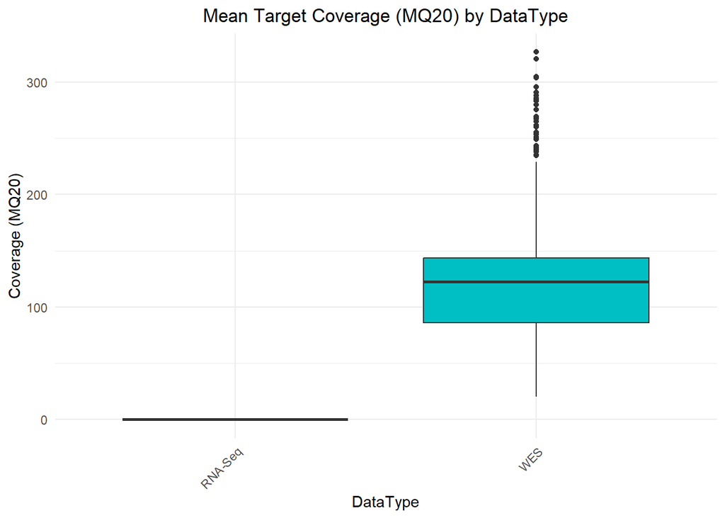

```r
# MQ20 -> This one does not really have an issue by itself, it's already clear that the MQ20 is only computed in WES
ggplot(data_clean, aes(x = DataType, y = `MeanTargetCoverage(MQ20)`, fill = DataType)) +
  geom_boxplot() +
  theme_minimal() +
  labs(
    title = "Mean Target Coverage (MQ20) by DataType",
    y = "Coverage (MQ20)"
  ) +
  theme(plot.title = element_text(hjust = 0.5),
        axis.text.x = element_text(angle = 45, hjust = 1),
        legend.position = "none")
```

All in all, all the variables lead us to the same conclusion, which is that there’s no much of a difference between RNA-Seq and WES techniques. If any, WES has more variability, but having seen the `summary()` and boxplots, we see a clear similar distribution. Hence, we can assure that the quality of both techniques is excellent.

## MSI_Tool differences

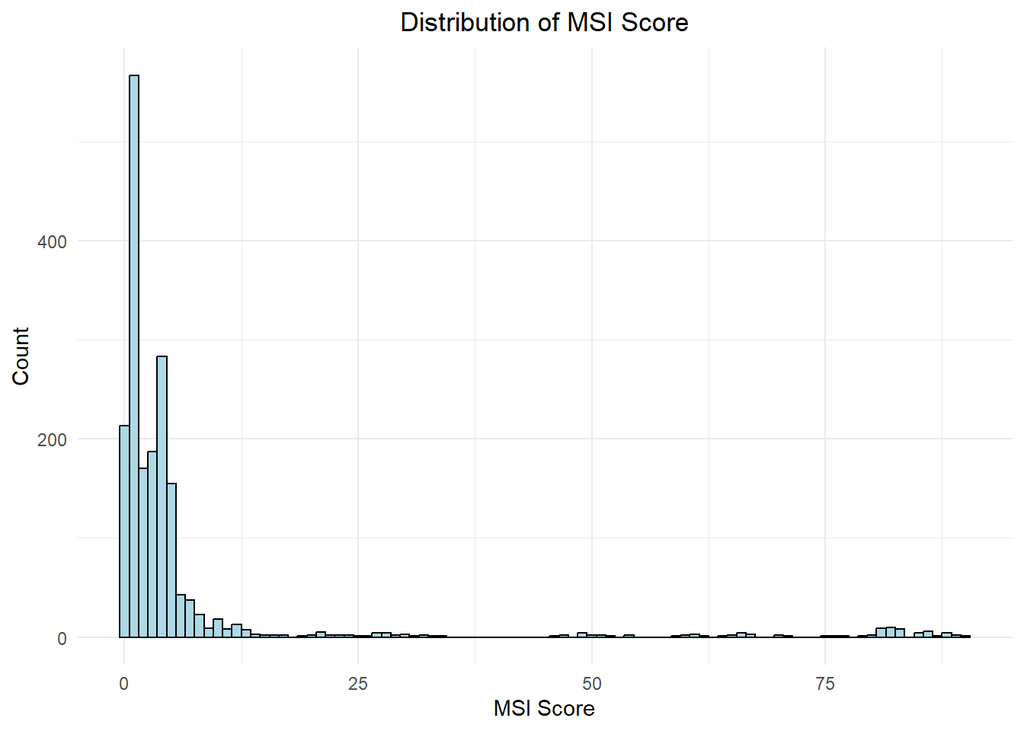

```r
ggplot(data_clean, aes(x = MSI_Score)) +
  geom_histogram(binwidth = 1, fill = "lightblue", color = "black", na.rm = TRUE) +
  theme_minimal() +
  labs(
    title = "Distribution of MSI Score",
    x = "MSI Score",
    y = "Count"
  ) +
  theme(plot.title = element_text(hjust = 0.5))
```

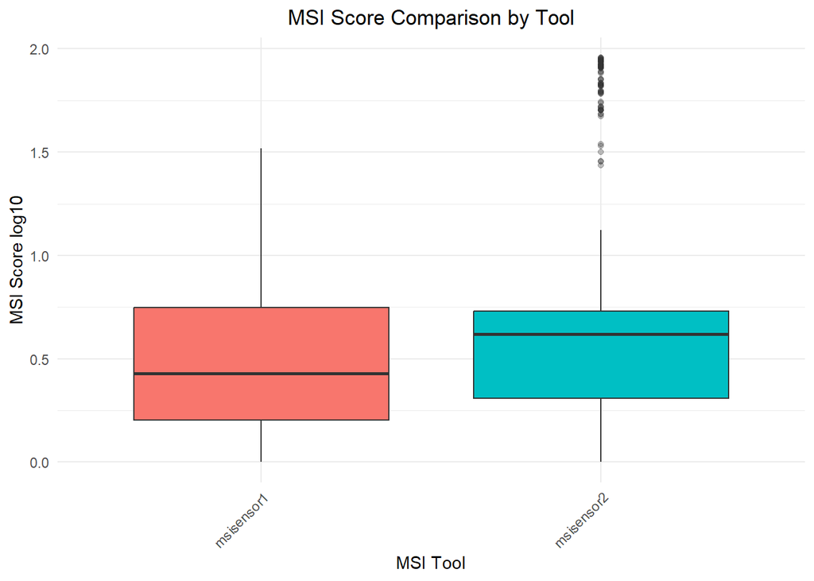

```r
data_msi <- data_clean %>%
  filter(!is.na(MSI_Score), !is.na(MSI_Tool))

# MSI_Score by MSI_Tool using Boxplots
ggplot(data_msi, aes(x = MSI_Tool, y = log10(MSI_Score + 1), fill = MSI_Tool)) +
  geom_boxplot(outlier.alpha = 0.3) +
  theme_minimal() +
  labs(
    title = "MSI Score Comparison by Tool",
    x = "MSI Tool",
    y = "MSI Score log10",
    fill = "MSI Tool"
  ) +
  theme(plot.title = element_text(hjust = 0.5),
        axis.text.x = element_text(angle = 45, hjust = 1),
        legend.position = "none")
```

In the case of the MSI Score we see a small issue at first, which is, like we had with the previous part, that we have many outliers (as clearly seen in the histogram), hence, we can perform a simple log10 transformation for a better visualization.

After doing so, we observe very similar distributions, so we conclude the same as before, for later tumor characterization graphics, we can consider those tumors computed with msisensor 1 and 2 as the same type.

All in all, in both cases we observe scores < 10, so most of the samples have a Low Instability, that is, the tumor has some replication errors (hypermutated, but not that much), just more than a regular cell.

## Ploidy and MSI_Score missing values

Something we were able to see in the `summary()` was that there were a lot of NAs in Ploidy and MSI_Score. A final question before actually starting the tumor characterization is to find where these NAs come from.

The first idea that we could think is that there may be a relation between Data Type and NAs. Maybe a technique did not take into account the Ploidy and/or the MSI_Score.

We can then plot side by side with histograms the relation between total samples for each test and it’s missing values. To do this, we must consider:

- **X-axis:** Metric (e.g., MSI or Ploidy)
- **Y-axis:** Counts of samples
- **Facets:** Separate plots by **Data Type** using `facet_wrap`
- **Fill color:** Distinguish values that are **NA** versus non-missing

To do so, we will do a “long_format Data Frame twice”, that is, first we do a Data Frame by the Metric (“smaller comparison”) and then by the Data Type (“bigger comparison”). Although we will directly perform a “summary table” for this second case, so we have all the values organized and ready to feed the bar plot.

```r
# Long Format of the Metric
data_missing <- data_clean %>%
  pivot_longer(cols = c(MSI_Score, Ploidy),
               names_to = "Metric",
               values_to = "Value") %>%
  mutate(Missing = is.na(Value)) # To take into account the NA value!! Creates a column "Missing" Where we will store either if the values is NA or not

# Long Format Summary Table by Data Type
summary_missing <- data_missing %>%
  group_by(DataType, Metric) %>% # We first group DataType and Metric together
  summarise( # We create a reduced + Simplified table with all the counts for each DataType + Metric + Type
    MissingCount = sum(Missing), # To sum all NAs into a variable called MissingCount
    TotalCount = n(),             # To sum all the rows in the group_by done (All rows of the data)
    .groups = "drop_last"
    ) %>%
  pivot_longer(cols = c(MissingCount, TotalCount), # We perform a new long format
               names_to = "Type",                  # Here we store the type of Count (new column)
               values_to = "Count")                # Here we store the numerical value (new column)


# We use the summary_missing data frame we just created
summary_missing %>%
  # We arrange to keep groups together
  arrange(DataType, Metric, desc(Type)) %>%
  kable(
    col.names = c("Data Category", "Metric Type", "Count Category", "Value"),
    caption = "<center><b>Detailed Missingness Summary by Data Type<center><b>",
    align = "lllr" # Left align text, Right align numbers
  ) %>%
  kable_styling(
    bootstrap_options = c("striped", "hover", "condensed"),
    full_width = TRUE
  ) %>%
  # This automatically merges the repeating 'DataType' cells for a cleaner look
  collapse_rows(columns = 1:2, valign = "top") %>%
  # Add a background color to the "Total Samples" rows to distinguish them
  row_spec(which(summary_missing$Type == "TotalCount"), background = "#f9f9f9") %>%
  # Highlight the header
  row_spec(0, bold = T, color = "white", background = "#2780e3")
```

**Detailed Missingness Summary by Data Type**

| Data Category | Metric Type | Count Category | Value |
| --- | --- | --- | --- |
| RNA-Seq | MSI_Score | TotalCount | 1551 |
|  |  | MissingCount | 1551 |
|  | Ploidy | TotalCount | 1551 |
|  |  | MissingCount | 1551 |
| WES | MSI_Score | TotalCount | 2154 |
|  |  | MissingCount | 293 |
|  | Ploidy | TotalCount | 2154 |
|  |  | MissingCount | 300 |

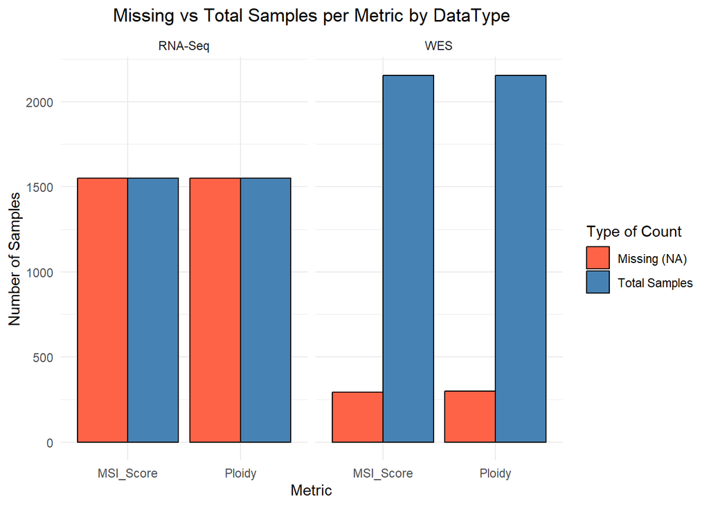

```r
# Histogram side by side
ggplot(summary_missing, aes(x = Metric, y = Count, fill = Type)) +
  geom_bar(stat = "identity", position = "dodge", color = "black") +
    # Stat = "identity" because we already computed the Counts in the "Count" column - No need for ggplot to               count the rows
    # Position dodge so that they do not overlap
  facet_wrap(~DataType) +
  scale_fill_manual(values = c("MissingCount" = "tomato", "TotalCount" = "steelblue"),
                    labels = c("Missing (NA)", "Total Samples")) +
  theme_minimal() +
  labs(title = "Missing vs Total Samples per Metric by DataType",
       x = "Metric",
       y = "Number of Samples",
       fill = "Type of Count") +
  theme(plot.title = element_text(hjust = 0.5))
```

But this supposes no problem for our study, as we have shown and concluded before, we can treat all RNA-Seq/WES samples as of the same type, given they have no Quality difference. So even if the RNA-Seq performed no Ploidy or MSI_Score, we can still study the tumor characterization.

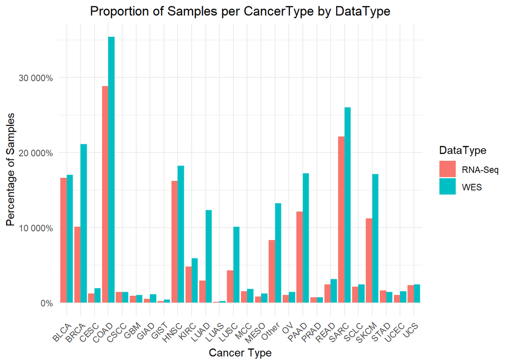

```r
# Side-by-side bar plot
ggplot(data_clean, aes(x = CancerType, fill = DataType)) +
  geom_bar(position = "dodge") +
  scale_y_continuous(labels = scales::percent_format(accuracy = 1)) +  # show as %
  theme_minimal() +
  labs(
    title = "Proportion of Samples per CancerType by DataType",
    x = "Cancer Type",
    y = "Percentage of Samples",
    fill = "DataType"
  ) +
  theme(
    axis.text.x = element_text(angle = 45, hjust = 1),
    plot.title = element_text(hjust = 0.5)
  )
```

## Tumors Characterization

We can now freely explore the Data we have but been careful and only take into considerations, the Human_Tumor group unless we want to explore differences between PDX (Xenographs) and Human_Tumor.

In this case we can study the distribution of the variables as they are or make small comparisons (in all cases, data was specified in such a way to eliminate NAs to be computed in the graphs too):

```r
# We first create the Subset for all the following graphs
data_filtered <- data %>%
  filter(Group == "Human_Tumor") %>%
  distinct(Formal_CaseID, .keep_all = TRUE)
```

### **Age Distribution**

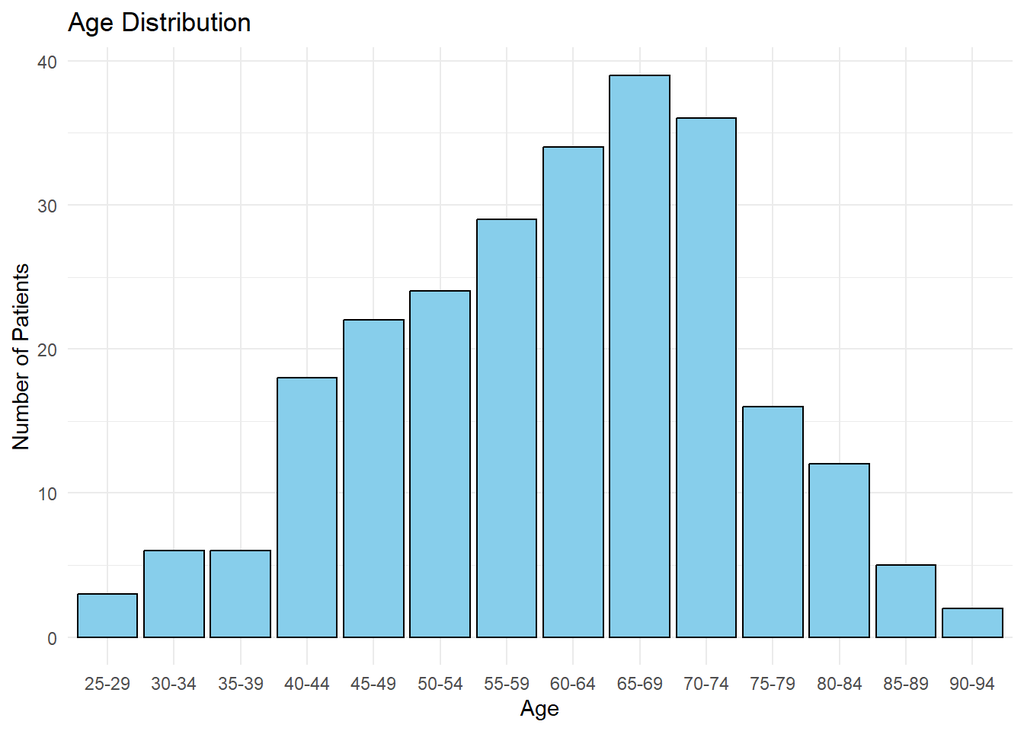

```r
ggplot(data_filtered[!is.na(data_filtered$Age), ], aes(x = Age)) +
  geom_bar(na.rm = TRUE, stat = 'count', fill = "skyblue", color = "black") +
  theme_minimal() +
  labs(title = "Age Distribution",
       x = "Age",
       y = "Number of Patients")
```

Quite a normally distributed age centralizing at 65.

### **Race Distribution**

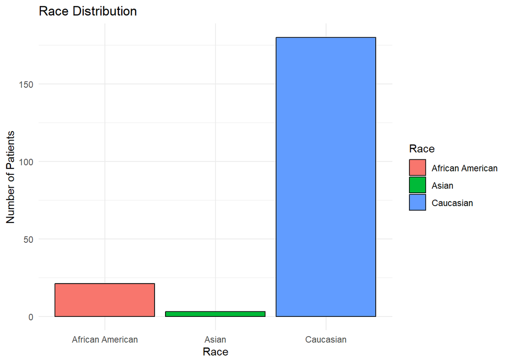

```r
ggplot(data_filtered[!is.na(data_filtered$Race), ], aes(x = Race, fill = Race)) +
  geom_bar(color = "black") +
  theme_minimal() +
  labs(title = "Race Distribution",
       x = "Race",
       y = "Number of Patients")
```

There’s a clear over expression of Caucasian patients over the rest.

### **Gender Distribution**

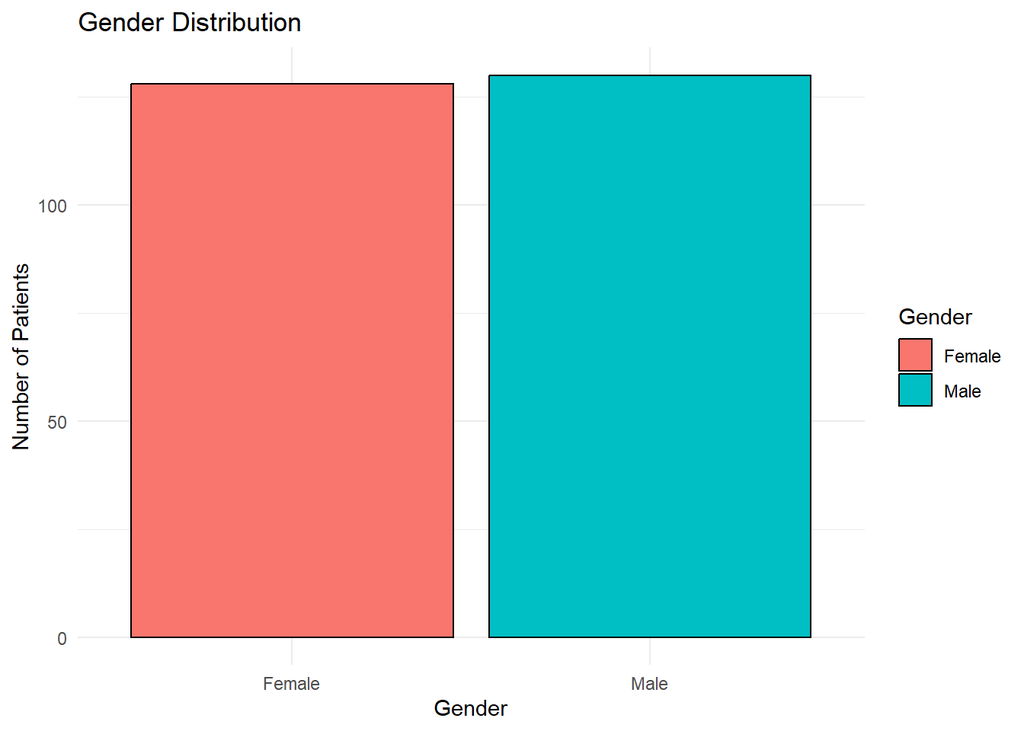

```r
ggplot(data_filtered[!is.na(data_filtered$Gender), ], aes(x = Gender, fill = Gender)) +
  geom_bar(color = "black") +
  theme_minimal() +
  labs(title = "Gender Distribution",
       x = "Gender",
       y = "Number of Patients")
```

We have equal number of Males and Females in the study.

### **Cancer Group Distribution**

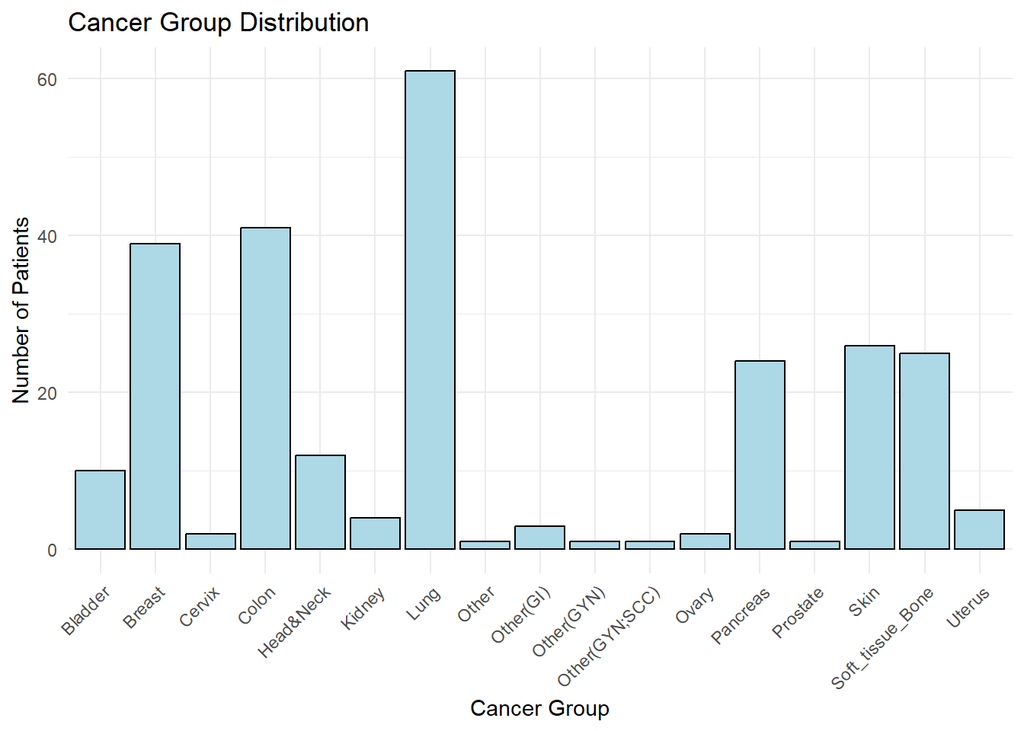

```r
ggplot(data_filtered[!is.na(data_filtered$CancerGroup), ], aes(x = CancerGroup)) +
  geom_bar(stat = 'count', fill = "lightblue", color = "black") +
  theme_minimal() +
  labs(title = "Cancer Group Distribution",
       x = "Cancer Group",
       y = "Number of Patients") +
  theme(
    axis.text.x = element_text(angle = 45, hjust = 1)
  )
```

Some cancers are more represented than others

### **Tumor Status vs Age**

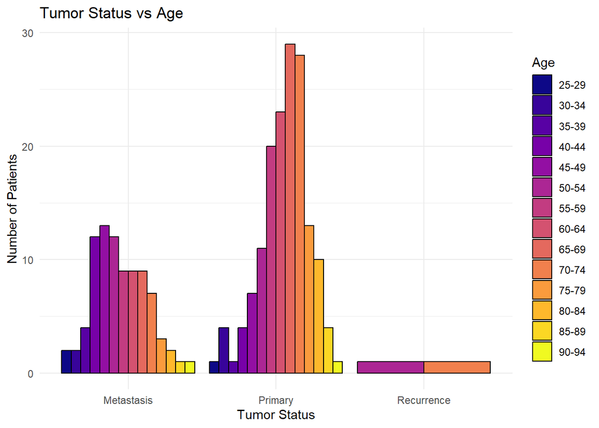

```r
ggplot(data_filtered[!is.na(data_filtered$TumorStatus) & !is.na(data_filtered$Age), ],
       aes(x = TumorStatus, fill = Age)) +
  geom_bar(position = "dodge", color = "black") +
  theme_minimal() +
  labs(title = "Tumor Status vs Age",
       x = "Tumor Status",
       y = "Number of Patients") +
  scale_fill_viridis_d(option = "C")
```

Curiously, metastasis patients are more evenly distributed, while primary ones are much more common at older ages.

### **Tumor Status vs Cancer Group**

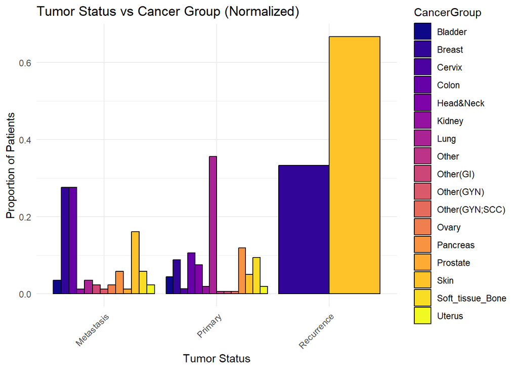

```r
# In this case is extremely important to first normalize the data or else we can see clear differences just because some types of cancers are more present than others in our data.
data_ratio <- data_filtered %>%
  filter(!is.na(TumorStatus) & !is.na(CancerGroup)) %>% # We exclude the NAs
  group_by(TumorStatus, CancerGroup) %>%                # We group by the variable we want to compare
  summarise(count = n(), .groups = "drop") %>%          # We count them
  group_by(TumorStatus) %>%                             # We regroup in TumorStatus
  mutate(proportion = count / sum(count))               # We add a new column with the normalized proportions

ggplot(data_ratio, aes(x = TumorStatus, y = proportion, fill = CancerGroup)) +
  geom_bar(stat = "identity", color = "black", position = "dodge") +
  theme_minimal() +
  labs(title = "Tumor Status vs Cancer Group (Normalized)",
       x = "Tumor Status",
       y = "Proportion of Patients") +
  scale_fill_viridis_d(option = "C") +
  theme(axis.text.x = element_text(angle = 45, hjust = 1))
```

### **Tumor Status vs Treatment Prior**

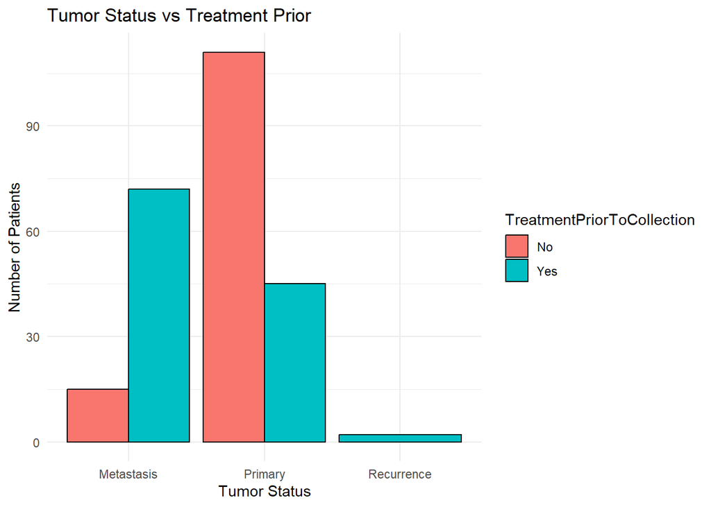

```r
ggplot(data_filtered[!is.na(data_filtered$TumorStatus) & !is.na(data_filtered$TreatmentPriorToCollection), ],
       aes(x = TumorStatus, fill = TreatmentPriorToCollection)) +
  geom_bar(position = "dodge", color = "black") +
  theme_minimal() +
  labs(title = "Tumor Status vs Treatment Prior",
       x = "Tumor Status",
       y = "Number of Patients")
```

Interestingly, Metastatic patients are the ones which have gone though more treatment rather than primary patients.

### **Tumor Status vs Ploidy**

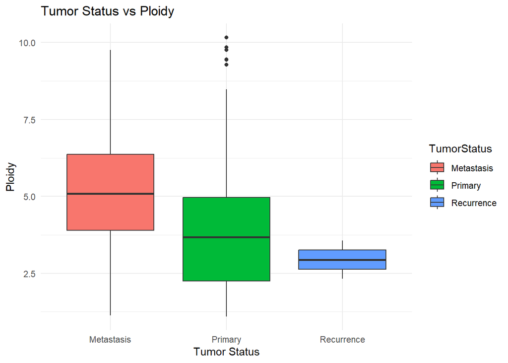

```r
ggplot(data_filtered[!is.na(data_filtered$TumorStatus) & !is.na(data_filtered$Ploidy), ],
       aes(x = TumorStatus, y = Ploidy, fill = TumorStatus)) +
  geom_boxplot() +
  theme_minimal() +
  labs(title = "Tumor Status vs Ploidy",
       x = "Tumor Status",
       y = "Ploidy")
```

It is not surprising to see how, those “more dangerous” forms of cancer, in this case, Metastasis, have the most Ploidy. Recall how the bigger the Ploidy, the worse the cancer is.

## **Final Graph 1 - DataType differences**

### **Motivation**

Even if the most “interesting” part in this project would be to see all the differences or similarities between the Tumors, Groups, Ages, etc. It is truly important to also consider, at least a bit, the Genomics side of the project as a Quality Check (Quality Control). In other words, if we do not demonstrate that all samples are equally good. We cannot perform a good further analysis.

### **Hypothesis**

We believe there should NOT be many differences in quality between DataType (RNA-Seq and WES), after all, what matters in these kind of analysis is the previous handling of the samples, which were performed all by the same team.

### **Graph**

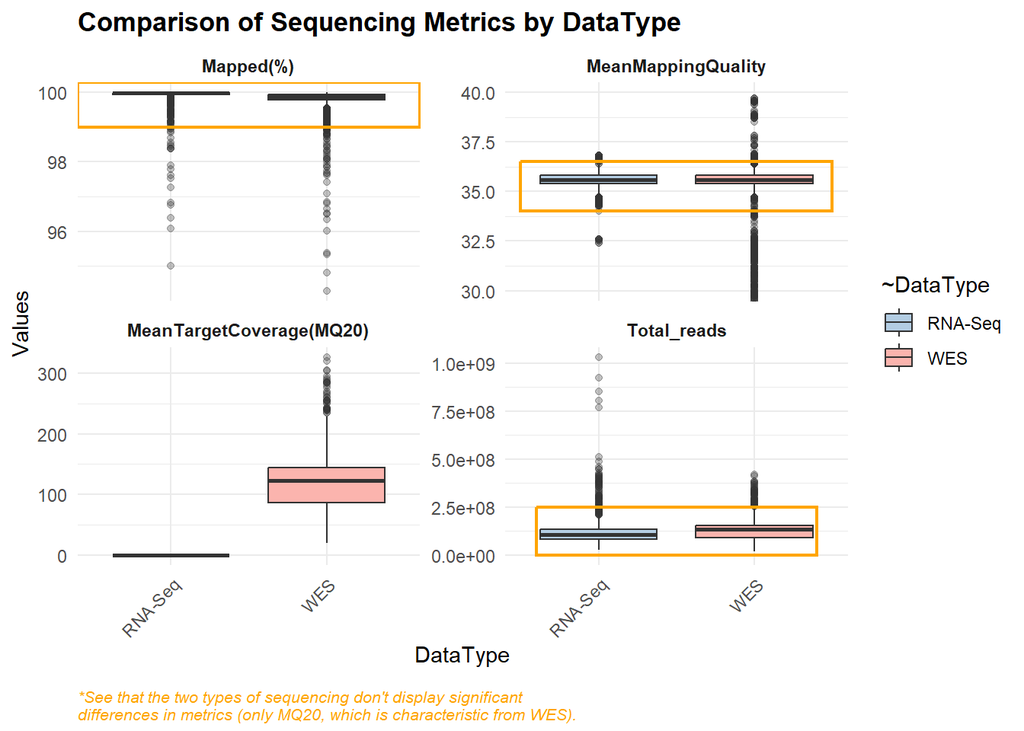

```r
# Select the QC-related variables
data_plot <- data_clean %>%
  select(DataType, Total_reads, `Mapped(%)`, MeanMappingQuality, `MeanTargetCoverage(MQ20)`) %>%
  # Convert to long format for easy comparison
  pivot_longer(
    cols = -DataType,
    names_to = "Metric",
    values_to = "Value"
  )

# Boxplots to compare the results
# Create annotation data frame with one row per facet
rect_annotations <- data.frame(
  Metric = c("Total_reads", "Mapped(%)", "MeanMappingQuality"),
  #              WES box         WES box         WES box
  xmin  = c(0.6,             -Inf,             0.5),
  xmax  = c(2.4,             Inf,             2.5),
  ymin  = c(0.0e+00,         99,              34),
  ymax  = c(2.5e+08,         Inf,              36.5)
)

text_annotations <- data.frame(
  Metric = "MeanMappingQuality",
  x = 2.4,
  y = 39.5,
  label = "*See that the two types of sequencing don't display\nsignificant differences in metrics (only MQ20,\nwhich is characteristic from WES)."
)

ggplot(data_plot, aes(x = DataType, y = Value, fill = DataType)) +
  geom_boxplot(outlier.alpha = 0.3) +
  geom_rect(
    data = rect_annotations,
    aes(xmin = xmin, xmax = xmax, ymin = ymin, ymax = ymax),
    inherit.aes = FALSE,
    alpha = 0,
    color = "orange",
    linewidth = 0.8
  ) +
  scale_fill_brewer(aes(fill = DataType), palette = "Pastel1",  direction = -1) +
  facet_wrap(~Metric, scales = "free_y") +
  scale_y_facet(Metric == "MeanMappingQuality", limits = c(30, 40)) +
  theme_minimal() +
  labs(
    title = "Comparison of Sequencing Metrics by DataType",
    x = "DataType",
    y = "Values",
    fill = "DataType",
    caption = "*See that the two types of sequencing don't display significant\ndifferences in metrics (only MQ20, which is characteristic from WES)."
  ) +
  theme(
    plot.title = element_text(face = "bold"),
    axis.text.x = element_text(angle = 45, hjust = 1),
    strip.text = element_text(face = "bold"),
    plot.caption = element_text(
      color = "orange",
      hjust = 0,
      vjust = 0,
      size = 8,
      face = "italic",
      margin = margin(t = 10)
    )
  )
```

### **Interpretation**

With the exception of the MQ20 (which is only computed on the WES samples), the other indicators of quality of the samples are, first of all, extremely similar and, second of all, extremely good. Having amazing Mapped(%) and MeanMappingQuality. In the case of the Total Reads, although there are clear outliers, they both follow the same trend. So our hypothesis was quite right.

## **Final Graph 2 - Most Prevalence Cancer Type per Age and Gender**

### **Motivation**

Even after analysing variables that are more centered on the form than on the content, we think it is of the utmost importance to extract significant clinical conclusions by graphical examination of more complex and insightful variables.

In this case, we consider that finding out which cancers are most prevalent in each age group and sex is essential to characterise our dataset, so we are able to compare the empirical evidence of our selected study with the medical consensus.

### **Hypothesis**

Older age groups (60–74) will represent the peak prevalence bracket across most cancer types, with notable gender-specific differences in sex-linked cancers (e.g., breast, cervix, prostate, uterus) and some variation in younger age peaks for hormonally-driven cancers.

### **Graph**

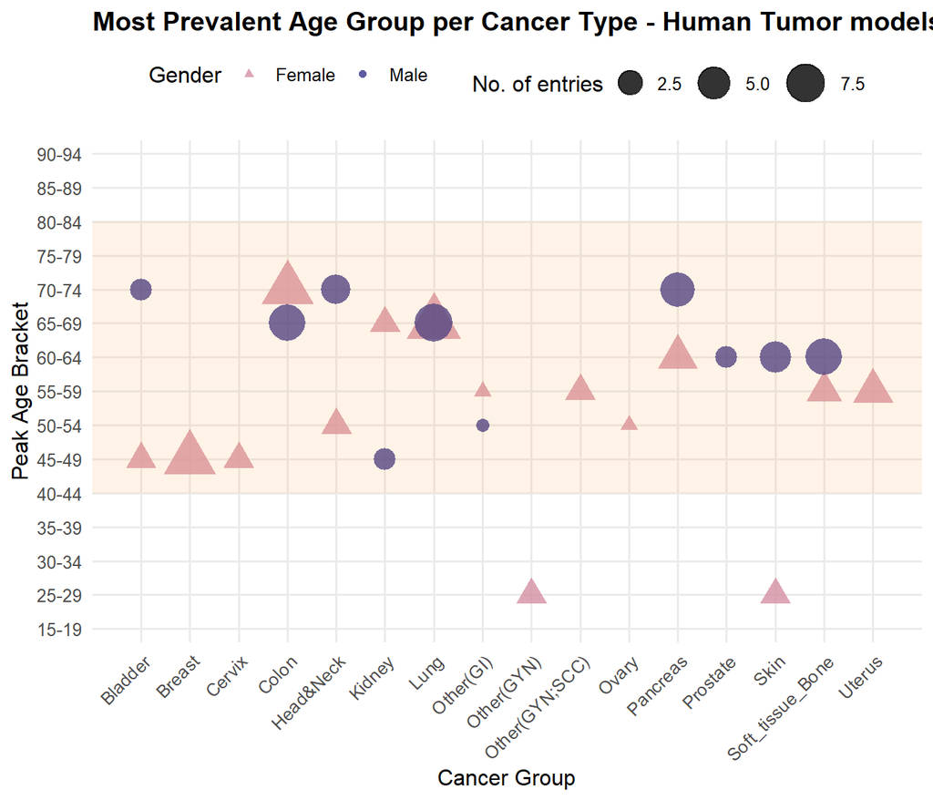

```r
data_clean %>%
  filter(
    !is.na(Age),
    !is.na(CancerGroup),
    !is.na(Gender),
    Group == "Human_Tumor"
  ) %>%
  count(CancerGroup, Age, Gender) %>%
  group_by(CancerGroup, Gender) %>%
  slice_max(n, n = 1, with_ties = FALSE) %>%
  ungroup() %>%
  ggplot(aes(x = CancerGroup, y = Age, color = Gender, size = n, shape = Gender)) +
  geom_point(alpha = 0.8) +
  scale_color_manual(values = c("Female" = "#D490A3", "Male" = "#37348A")) +
  scale_shape_manual(values = c("Female" = 17, "Male" = 16)) +
  scale_size_continuous(range = c(3, 10), name = "No. of entries") +
  scale_y_discrete(drop = FALSE, expand = expansion(add = 0.4)) +
  labs(
    title = "Most Prevalent Age Group per Cancer Type - Human Tumor models",
    x = "Cancer Group", y = "Peak Age Bracket", color = "Gender", shape = "Gender"
  ) +
  annotate("rect", xmin = 0, xmax = 17, ymin = 5, ymax = 13, alpha = 0.15, fill = '#FFA756') +
  theme_minimal(base_size = 12) +
  theme(
    plot.title = element_text(face = "bold"),
    axis.text.x = element_text(angle = 45, hjust = 1),
    legend.position = "top"
  )
```

### **Interpretation**

Breast cancer peaks unexpectedly early at 45–49, with one of the largest dot sizes, which suggests high study representation of premenopausal or early postmenopausal women in these tumor models. This can also be an indicator of good change in practice, screening for these types of cancers earlier than it was used to.

To follow up, other(GYN) shows a very young female peak around 25–29, possibly reflecting rare gynecological malignancies like germ cell tumors, those being more common in younger women.

We can conclude that while aging is the dominant risk factor across most cancers, hormonal and reproductive cancers display different behaviour. It is also clear that starting from 45-49, more cancer cases are registered, which is clearly seen in the graph.

## **Final Graph 3 - Ploidy / Cancer Group by Group (Human Tumor and PDX)**

### **Motivation**

We have just focused on variables regarding the Human_Tumor group, which is the main one, although the paper focuses also on PDX. Hence, something we could check is if there’s actually any difference between the Cancer Groups + Ploidy and if the cells are from the Human itself or the Xenograph.

### **Hypothesis**

We believe there should NOT be many differences of Ploidy + Cancer Groups between Human and PDX. After all, the PDX was originally obtained from those humans (then implanted into mice), so it makes sense they have the same Ploidy.

### **Graph**

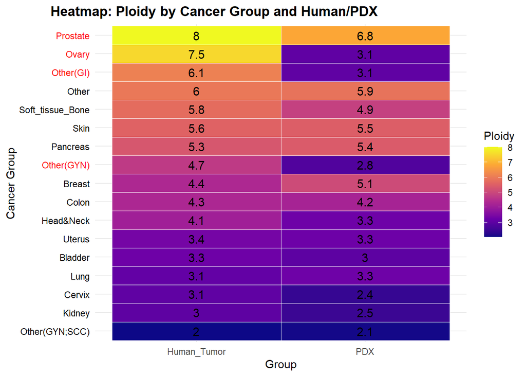

```r
# We will ONLY use those PDX patients that intersect with Human_Tumor (that is, all Human_Tumor patients)

# We obtained all those rows (unique) from Human_Tumor
human_tumor_data <- data %>%
  filter(Group == "Human_Tumor") %>%
  distinct(Formal_CaseID, .keep_all = TRUE)  # one row per patient

# We obtained all those rows (unique) from PDX BUT filtering that they must be with the same Patient ID than Human_Tumor
pdx_data <- data %>%
  filter(Group == "PDX", Formal_CaseID %in% human_tumor_data$Formal_CaseID) %>%
  distinct(Formal_CaseID, .keep_all = TRUE)

# We combine them
combined_data <- bind_rows(human_tumor_data, pdx_data)

# We compute the mean of the ploidy (this will be useful to write the value inside each heatmap cell)
heatmap_data <- combined_data %>%
  group_by(Group, CancerGroup) %>%
  summarise(Ploidy_value = mean(Ploidy, na.rm = TRUE), .groups = "drop")

order_levels <- heatmap_data %>%
  filter(Group == "Human_Tumor") %>%
  arrange(Ploidy_value) %>%
  pull(CancerGroup)

heatmap_data$CancerGroup <- factor(heatmap_data$CancerGroup, levels = order_levels)

# We annotate the plot to highlight specific cancer groups
highlight_cancers <- c("Ovary", "Prostate", "Other(GYN)", "Other(GI)")

y_levels <- sort(unique(heatmap_data$CancerGroup))
y_colors <- ifelse(y_levels %in% highlight_cancers, "red", "black")

# We perform the heatmap
ggplot(heatmap_data, aes(x = Group, y = CancerGroup, fill = Ploidy_value)) +
  geom_tile(color = "white") +
  geom_text(aes(label = round(Ploidy_value, 1)), color = "black", size = 4) +
  scale_fill_viridis_c(option = "C") +
  theme_minimal() +
  labs(title = "Heatmap: Ploidy by Cancer Group and Human/PDX",
       x = "Group",
       y = "Cancer Group",
       fill = "Ploidy") +
  theme(plot.title = element_text(face = "bold", hjust = -1),
        axis.text.y = element_text(colour = y_colors))
```

### **Interpretation**

As we can see, in general, most of the Cancer Groups follow the same ploidy between Human_Tumor and PDX samples. Although there are some cases like Ovary, Other(GI and GYN) or Prostate where the differences are sharper.

Nevertheless, there’s a small tendency of “decay” in Ploidy in PDX. We could interpret that when the Xenograph is created, due to the new environment, the Tumor is not as “dangerous” as it initially was in the Human.